## 3. Representation cartographique des donnees

```r
# GeoNature

GN_sf <- Total %>%
  dplyr::filter(bdd_originale == GN)

grid_sf <- sf::st_sf(geometry = st_make_grid(carte_bretagne,
                                         cellsize = c(0.12, 0.09))
              )
grid_sf$density <- lengths(st_intersects(grid_sf, GN_sf))
grid_sf <- st_intersection(grid_sf, carte_bretagne)
```

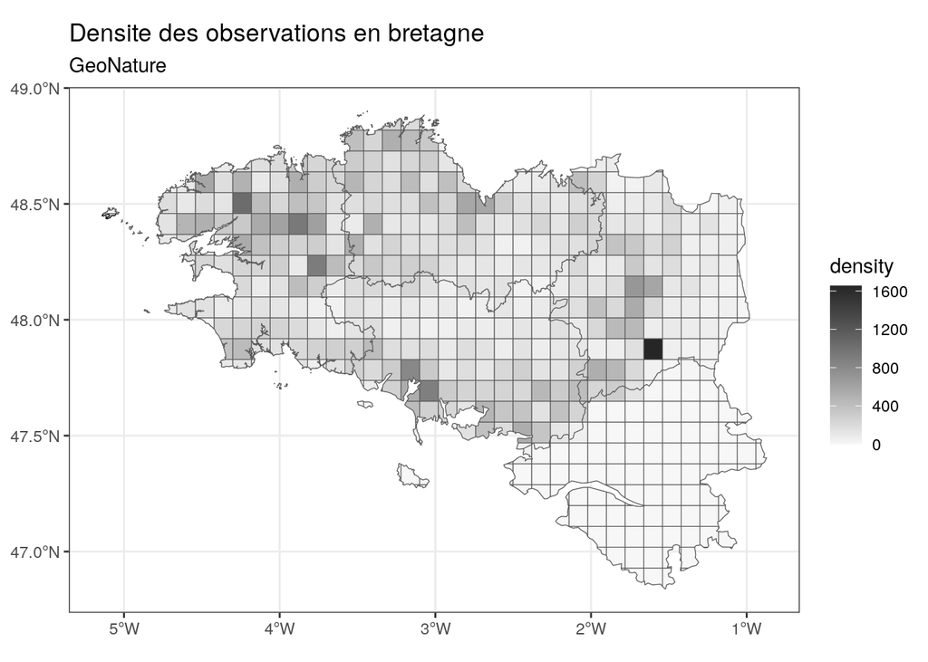

```r
ggplot2::ggplot() +
  geom_sf(data = carte_bretagne) +
  labs(title = "Densite des observations en bretagne",
       subtitle = GN) +
  geom_sf(data = grid_sf, aes(fill = density)) +
  scale_fill_gradient(low="gray97", high="gray15") +
  theme_bw()
```

```r
# VisioNature

VN_sf <- Total %>%
  dplyr::filter(bdd_originale == VN)

grid_sf <- sf::st_sf(geometry = st_make_grid(carte_bretagne,
                                         cellsize = c(0.12, 0.09)))
grid_sf$density <- lengths(st_intersects(grid_sf, VN_sf))
grid_sf <- sf::st_intersection(grid_sf, carte_bretagne)
```

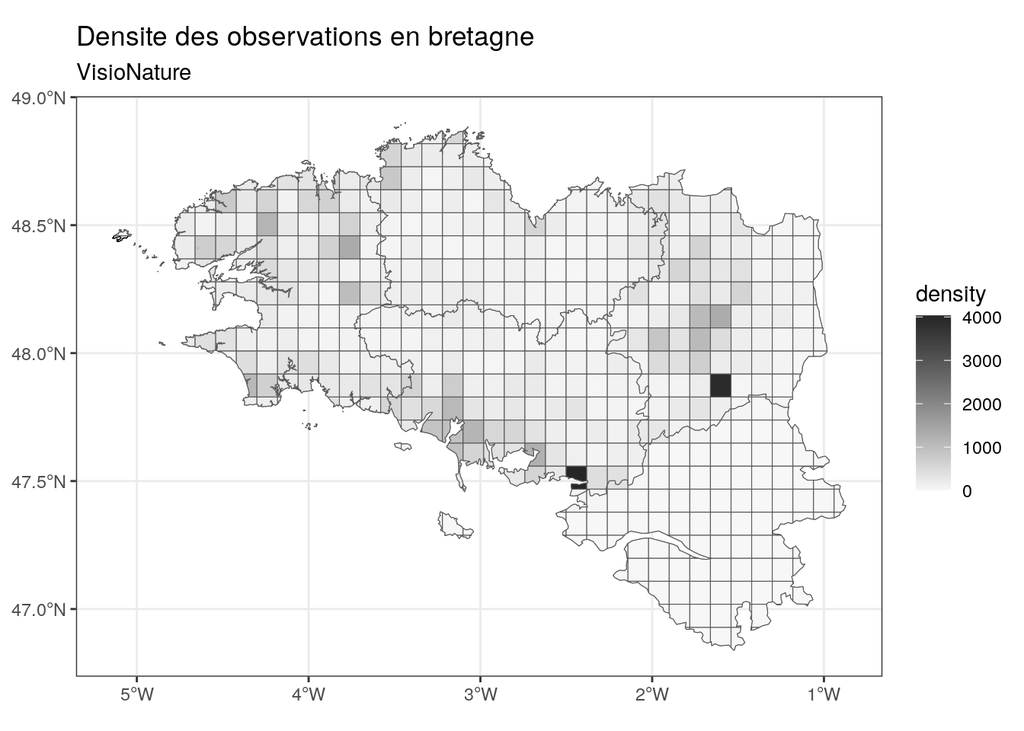

```r
ggplot2::ggplot() +
  geom_sf(data = carte_bretagne) +
  labs(title = "Densite des observations en bretagne",
       subtitle = VN) +
  geom_sf(data = grid_sf, aes(fill = density)) +
  scale_fill_gradient(low="grey97", high="gray15") +
  theme_bw()
```

Dans VisioNature, on a deux points avec une tres forte densite sont probablement dues a nos deux principaux contributeurs (voir la partie 4), nous decidons de les supprimer pour verifier.

```r
VN_sf_modif <- VN_sf%>%
  dplyr::filter(!observateurs %in% c("BELLIER_DANIEL", "CHAPUIS_MARTINE"))

grid_sf <- sf::st_sf(geometry = st_make_grid(carte_bretagne,
                                         cellsize = c(0.12, 0.09))
)
grid_sf$density <- lengths(st_intersects(grid_sf, VN_sf_modif))
grid_sf <- sf::st_intersection(grid_sf, carte_bretagne)
```

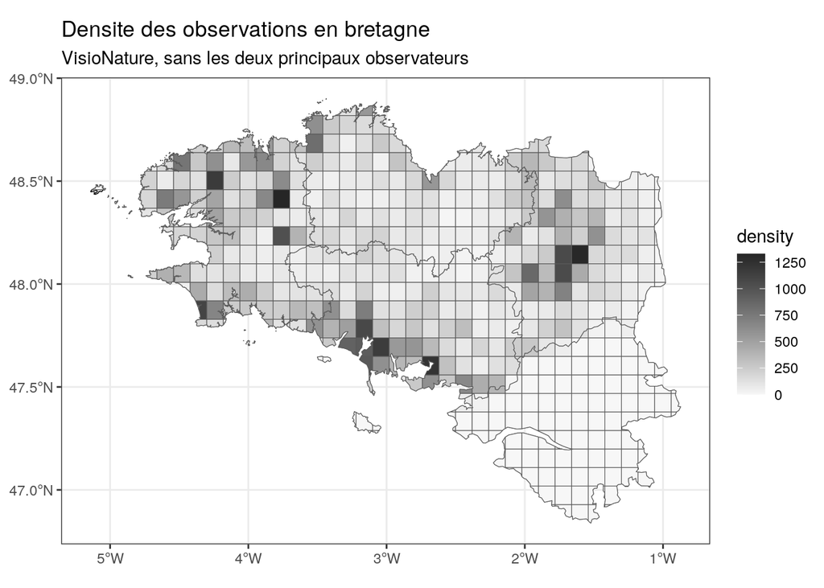

```r
ggplot2::ggplot() +
  geom_sf(data = carte_bretagne) +
  labs(title = "Densite des observations en bretagne",
       subtitle = "VisioNature, sans les deux principaux observateurs") +
  geom_sf(data = grid_sf, aes(fill = density)) +
  scale_fill_gradient(low="grey97", high="gray15") +
  theme_bw()
```

```r
# Donnees geographique

GN_sf <- Total%>%
  dplyr::filter(bdd_originale == GN)%>%
  dplyr::select(ordre, date)

VN_sf <- Total%>%
  dplyr::filter(bdd_originale == VN)%>%
  dplyr::select(ordre, date)

ordres <- unique(VN_sf$ordre)

grid <- sf::st_make_grid(carte_bretagne,
                     cellsize = c(0.12, 0.09)) %>%
  sf::st_sf() %>%
  sf::st_set_crs(4326)
```

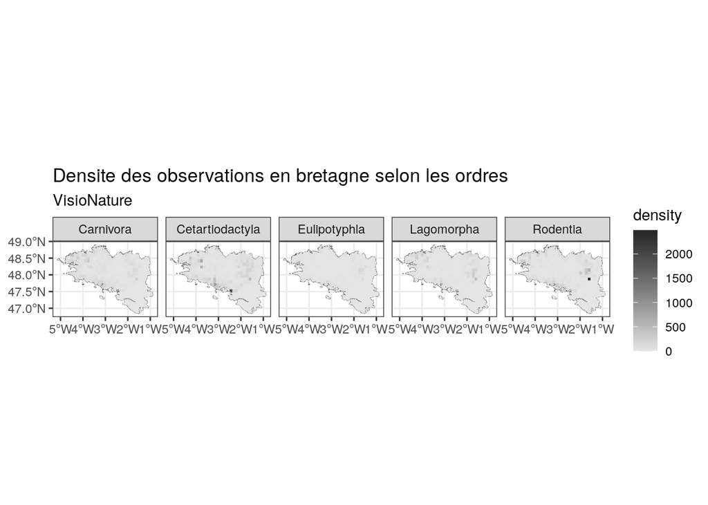

```r
grid_list <- purrr::map(ordres, function(o) {
  vis_ord <- VN_sf %>% dplyr::filter(ordre == o)
  grid_tmp <- grid
  grid_tmp$density <- lengths(st_intersects(grid_tmp, vis_ord))
  grid_tmp$ordre <- o
  grid_tmp
})
grid_sf <- bind_rows(grid_list)
grid_sf <- sf::st_intersection(grid_sf, carte_bretagne)
ggplot() +
  geom_sf(data = carte_bretagne) +
  labs(title = "Densite des observations en bretagne selon les ordres",
       subtitle = VN) +
  geom_sf(data = grid_sf, aes(fill = density), color = NA) +
  scale_fill_gradient(low="gray90", high="gray15") +
  theme_bw() +
  facet_grid(. ~ ordre)
```

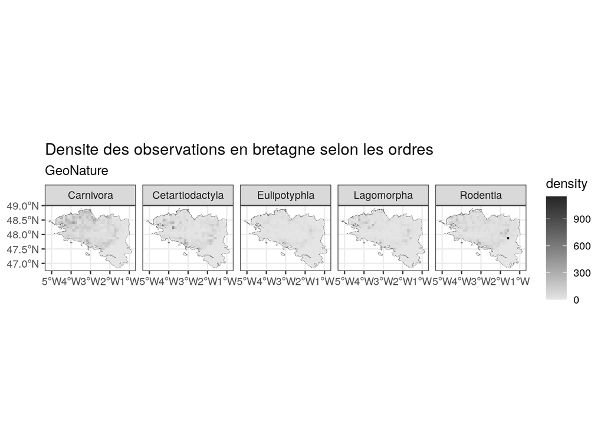

```r
# GeoNature
grid_list <- purrr::map(ordres, function(o) {
  vis_ord <- GN_sf %>% dplyr::filter(ordre == o)
  grid_tmp <- grid
  grid_tmp$density <- lengths(st_intersects(grid_tmp, vis_ord))
  grid_tmp$ordre <- o
  grid_tmp
})
grid_sf <- bind_rows(grid_list)
grid_sf <- st_intersection(grid_sf, carte_bretagne)
ggplot() +
  geom_sf(data = carte_bretagne) +
  labs(title = "Densite des observations en bretagne selon les ordres",
       subtitle = "GeoNature") +
  geom_sf(data = grid_sf, aes(fill = density), color = NA) +
  scale_fill_gradient(low="gray90", high="gray15") +
  theme_bw() +
  facet_grid(. ~ ordre)
```

On ne voit pas grand chose sur la carte de VisioNature a part les 2 principaux observateurs.. Concernant la base de donnees GeoNature, on dirait que les especes ont un peu pres la meme repartition en Bretagne (nord Finistere et Cote d’Armor et sud Ille-et-Vilaine et Morbihan)

Nous prenons la base de donnees avec toutes les donnees et je selectionne 40 000 ou 50 000 donnees avec les proportions.

Pour info, la graine aleatoire est figee a 12345.

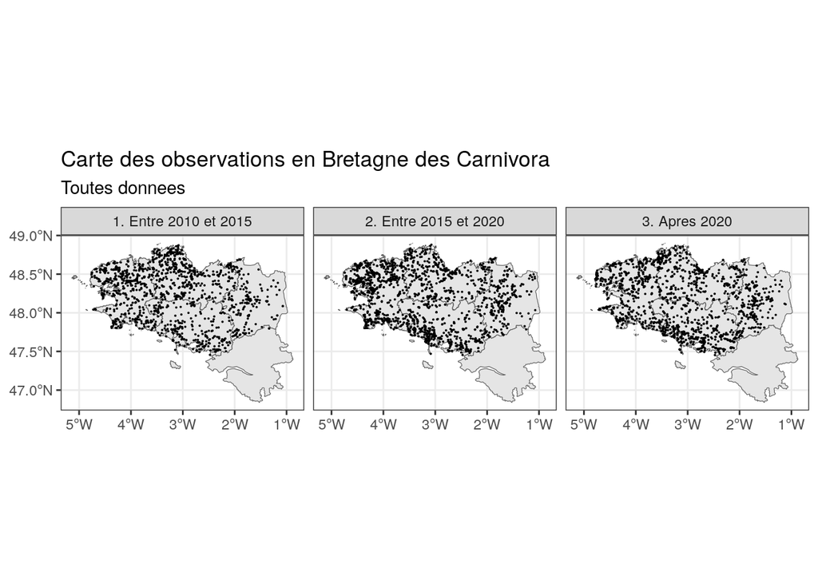

```r
graph_ordre_tranche_annee(bdd = Total, "Carnivora")
```

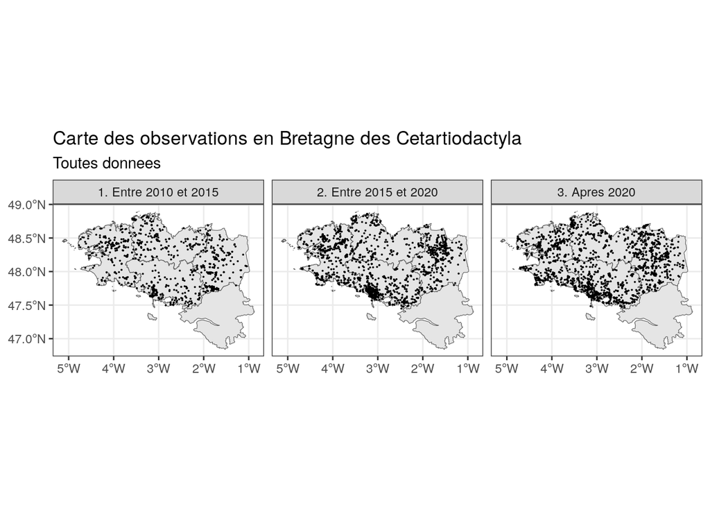

```r
graph_ordre_tranche_annee(bdd = Total, "Cetartiodactyla")
```

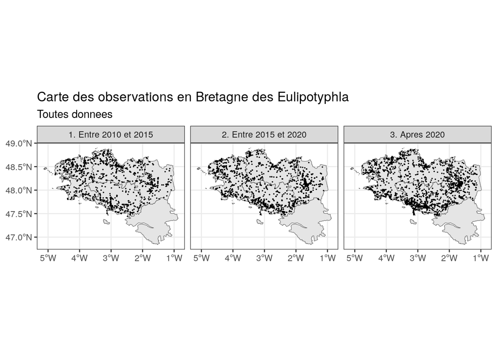

```r
graph_ordre_tranche_annee(bdd = Total, "Eulipotyphla")
```

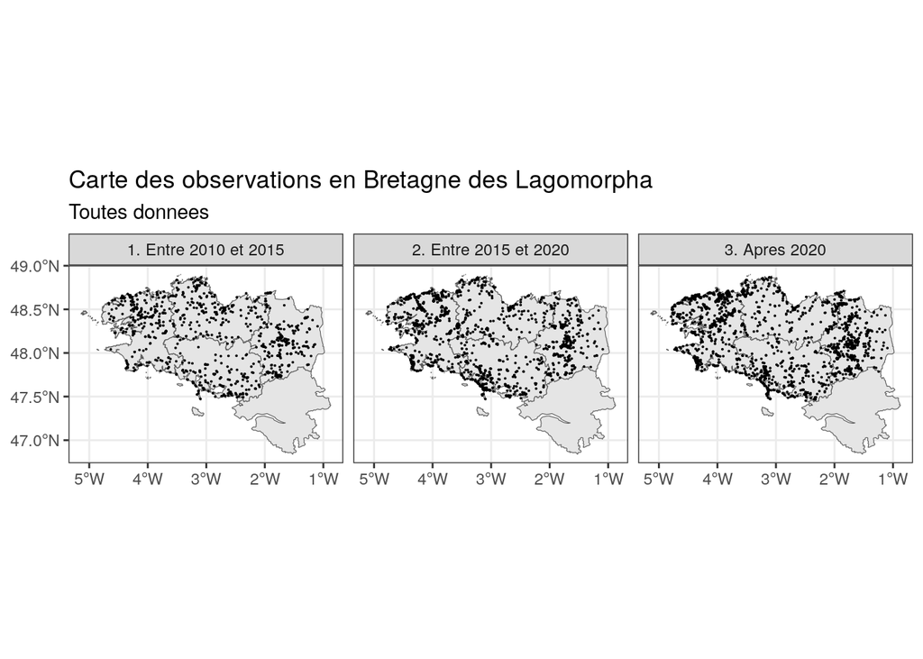

```r
graph_ordre_tranche_annee(bdd = Total, "Lagomorpha")
```

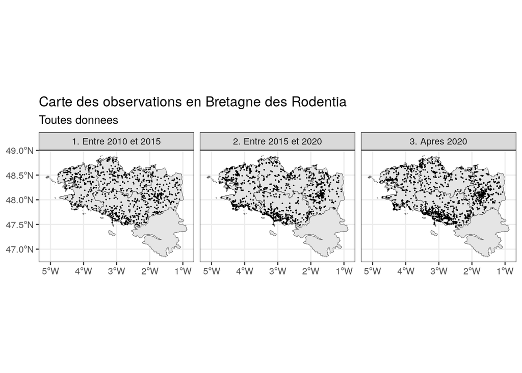

```r
graph_ordre_tranche_annee(bdd = Total, "Rodentia")
```

On dirait que plus on avance dans les annees, plus on retrouve d’individus aux sud de la Bretagne. Ceci peut etre car nous avons plus de donnees de VisioNature au fil du temps qui provient d’ornithologues et les ornithologues sont souvent proches des littoraux.